# World Happiness Analysis

> Statistics project

### june 2021

> Itay Zohar, Liri Bar-On, Amit Hadar

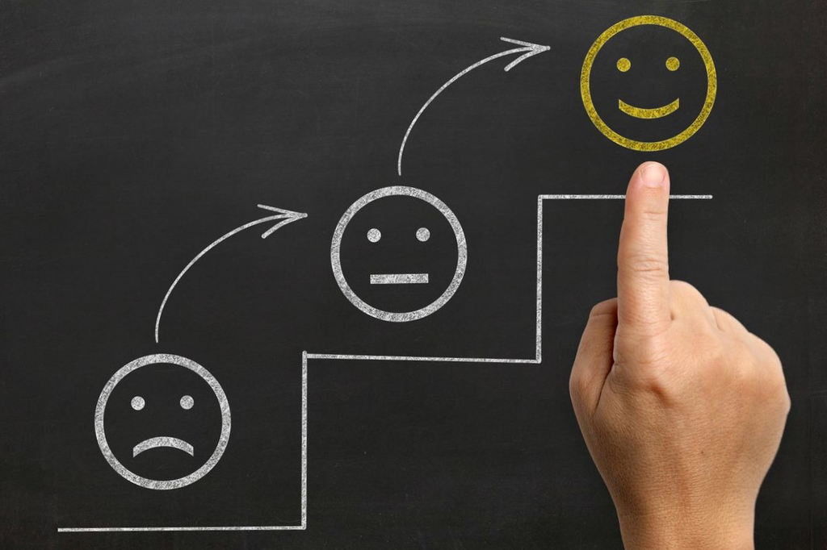

# Introduction

This article is a summery of our statistics project ([github link](https://github.com/MrPupik/StatisticsFinalProject/)), where we analyze the results of [world happiness reports (link)](https://worldhappiness.report/). In our research we focused on the years 2015 to 2021. The datasets we used can be found [here on Kaggle.](https://www.kaggle.com/mathurinache/world-happiness-report-20152021)

Since the data of each year came separately and included different categories and measurements, the first stage of our work is to **tidy our data**.

The next two stages are the heart of our article: Visualization and modeling. We will be making visualizations to explore the data, theorize about what we see, and prove/disprove our theories using statistical models and methods we learned throughoutthe course.

Our goal is to explore interesting facts of world happiness and what affects it and how. Questions we will focus on:

#### 1. Why are some countries happier than others? What makes a country “happy”?

- The connection between `life expectancy` (*health*) and *score*. Specificity, is the connection linear? (**linear regression model**)
- The connection between the `region or continent` (*region*) and happiness (**hypothesis testing, goodness of fit**)

#### 2. Happiness over the years

- Did Covid19 made our world sad? Comparison of 2019 and 2020 *scores* (**hypothesis testing, difference in means**)
- Which year was the happiest? Mean *score* over time.
- Connection between `GDP per capita` (*gdp*) and happiness - all years combined.
- Are we getting happier? Trends in mean *score* over the years.
- Changes in happiness per country. Which countries change the most?

# Data exploration and tidying

Initial setup and data import:

```r
library(tidyverse)
library(gridExtra)
data15 = readr::read_csv(file="data/2015.csv")
data16 = readr::read_csv(file="data/2016.csv")
data17 = readr::read_csv(file="data/2017.csv")
data18 = readr::read_csv(file="data/2018.csv")
data19 = readr::read_csv(file="data/2019.csv")
data20 = readr::read_csv(file="data/2020.csv")
data21 = readr::read_csv(file="data/2021.csv")
```

Now let’s have a glimpse of our dataset. we have 7 files, one for each year (2015-2021)

## Glimpse all data:

### 2015

```r
glimpse(data15)
```

```
## Rows: 158
## Columns: 12
## $ Country                         <chr> "Switzerland", "Iceland", "Denmark", "~
## $ Region                          <chr> "Western Europe", "Western Europe", "W~
## $ `Happiness Rank`                <dbl> 1, 2, 3, 4, 5, 6, 7, 8, 9, 10, 11, 12,~
## $ `Happiness Score`               <dbl> 7.587, 7.561, 7.527, 7.522, 7.427, 7.4~
## $ `Standard Error`                <dbl> 0.03411, 0.04884, 0.03328, 0.03880, 0.~
## $ `Economy (GDP per Capita)`      <dbl> 1.39651, 1.30232, 1.32548, 1.45900, 1.~
## $ Family                          <dbl> 1.34951, 1.40223, 1.36058, 1.33095, 1.~
## $ `Health (Life Expectancy)`      <dbl> 0.94143, 0.94784, 0.87464, 0.88521, 0.~
## $ Freedom                         <dbl> 0.66557, 0.62877, 0.64938, 0.66973, 0.~
## $ `Trust (Government Corruption)` <dbl> 0.41978, 0.14145, 0.48357, 0.36503, 0.~
## $ Generosity                      <dbl> 0.29678, 0.43630, 0.34139, 0.34699, 0.~
## $ `Dystopia Residual`             <dbl> 2.51738, 2.70201, 2.49204, 2.46531, 2.~
```

### 2016

```r
glimpse(data16)
```

```
## Rows: 157
## Columns: 13
## $ Country                         <chr> "Denmark", "Switzerland", "Iceland", "~
## $ Region                          <chr> "Western Europe", "Western Europe", "W~
## $ `Happiness Rank`                <dbl> 1, 2, 3, 4, 5, 6, 7, 8, 9, 10, 11, 12,~
## $ `Happiness Score`               <dbl> 7.526, 7.509, 7.501, 7.498, 7.413, 7.4~
## $ `Lower Confidence Interval`     <dbl> 7.460, 7.428, 7.333, 7.421, 7.351, 7.3~
## $ `Upper Confidence Interval`     <dbl> 7.592, 7.590, 7.669, 7.575, 7.475, 7.4~
## $ `Economy (GDP per Capita)`      <dbl> 1.44178, 1.52733, 1.42666, 1.57744, 1.~
## $ Family                          <dbl> 1.16374, 1.14524, 1.18326, 1.12690, 1.~
## $ `Health (Life Expectancy)`      <dbl> 0.79504, 0.86303, 0.86733, 0.79579, 0.~
## $ Freedom                         <dbl> 0.57941, 0.58557, 0.56624, 0.59609, 0.~
## $ `Trust (Government Corruption)` <dbl> 0.44453, 0.41203, 0.14975, 0.35776, 0.~
## $ Generosity                      <dbl> 0.36171, 0.28083, 0.47678, 0.37895, 0.~
## $ `Dystopia Residual`             <dbl> 2.73939, 2.69463, 2.83137, 2.66465, 2.~
```

### 2017

```r
glimpse(data17)
```

```
## Rows: 155
## Columns: 12
## $ Country                       <chr> "Norway", "Denmark", "Iceland", "Switzer~
## $ Happiness.Rank                <dbl> 1, 2, 3, 4, 5, 6, 7, 8, 9, 10, 11, 12, 1~
## $ Happiness.Score               <dbl> 7.537, 7.522, 7.504, 7.494, 7.469, 7.377~
## $ Whisker.high                  <dbl> 7.594445, 7.581728, 7.622030, 7.561772, ~
## $ Whisker.low                   <dbl> 7.479556, 7.462272, 7.385970, 7.426227, ~
## $ Economy..GDP.per.Capita.      <dbl> 1.616463, 1.482383, 1.480633, 1.564980, ~
## $ Family                        <dbl> 1.533524, 1.551122, 1.610574, 1.516912, ~
## $ Health..Life.Expectancy.      <dbl> 0.7966665, 0.7925655, 0.8335521, 0.85813~
## $ Freedom                       <dbl> 0.6354226, 0.6260067, 0.6271626, 0.62007~
## $ Generosity                    <dbl> 0.36201224, 0.35528049, 0.47554022, 0.29~
## $ Trust..Government.Corruption. <dbl> 0.31596383, 0.40077007, 0.15352656, 0.36~
## $ Dystopia.Residual             <dbl> 2.277027, 2.313707, 2.322715, 2.276716, ~
```

### 2018

```r
glimpse(data18)
```

```
## Rows: 156
## Columns: 9
## $ `Overall rank`                 <dbl> 1, 2, 3, 4, 5, 6, 7, 8, 9, 10, 11, 12, ~
## $ `Country or region`            <chr> "Finland", "Norway", "Denmark", "Icelan~
## $ Score                          <dbl> 7.632, 7.594, 7.555, 7.495, 7.487, 7.44~
## $ `GDP per capita`               <dbl> 1.305, 1.456, 1.351, 1.343, 1.420, 1.36~
## $ `Social support`               <dbl> 1.592, 1.582, 1.590, 1.644, 1.549, 1.48~
## $ `Healthy life expectancy`      <dbl> 0.874, 0.861, 0.868, 0.914, 0.927, 0.87~
## $ `Freedom to make life choices` <dbl> 0.681, 0.686, 0.683, 0.677, 0.660, 0.63~
## $ Generosity                     <dbl> 0.202, 0.286, 0.284, 0.353, 0.256, 0.33~
## $ `Perceptions of corruption`    <chr> "0.393", "0.340", "0.408", "0.138", "0.~
```

### 2019

```r
glimpse(data19)
```

```
## Rows: 156
## Columns: 9
## $ `Overall rank`                 <dbl> 1, 2, 3, 4, 5, 6, 7, 8, 9, 10, 11, 12, ~
## $ `Country or region`            <chr> "Finland", "Denmark", "Norway", "Icelan~
## $ Score                          <dbl> 7.769, 7.600, 7.554, 7.494, 7.488, 7.48~
## $ `GDP per capita`               <dbl> 1.340, 1.383, 1.488, 1.380, 1.396, 1.45~
## $ `Social support`               <dbl> 1.587, 1.573, 1.582, 1.624, 1.522, 1.52~
## $ `Healthy life expectancy`      <dbl> 0.986, 0.996, 1.028, 1.026, 0.999, 1.05~
## $ `Freedom to make life choices` <dbl> 0.596, 0.592, 0.603, 0.591, 0.557, 0.57~
## $ Generosity                     <dbl> 0.153, 0.252, 0.271, 0.354, 0.322, 0.26~
## $ `Perceptions of corruption`    <dbl> 0.393, 0.410, 0.341, 0.118, 0.298, 0.34~
```

### 2020

```r
glimpse(data20)
```

```
## Rows: 153
## Columns: 20
## $ `Country name`                               <chr> "Finland", "Denmark", "Sw~
## $ `Regional indicator`                         <chr> "Western Europe", "Wester~
## $ `Ladder score`                               <dbl> 7.8087, 7.6456, 7.5599, 7~
## $ `Standard error of ladder score`             <dbl> 0.03115630, 0.03349229, 0~
## $ upperwhisker                                 <dbl> 7.869766, 7.711245, 7.628~
## $ lowerwhisker                                 <dbl> 7.747634, 7.579955, 7.491~
## $ `Logged GDP per capita`                      <dbl> 10.639267, 10.774001, 10.~
## $ `Social support`                             <dbl> 0.9543297, 0.9559908, 0.9~
## $ `Healthy life expectancy`                    <dbl> 71.90083, 72.40250, 74.10~
## $ `Freedom to make life choices`               <dbl> 0.9491722, 0.9514443, 0.9~
## $ Generosity                                   <dbl> -0.059482019, 0.066201776~
## $ `Perceptions of corruption`                  <dbl> 0.1954446, 0.1684895, 0.3~
## $ `Ladder score in Dystopia`                   <dbl> 1.972317, 1.972317, 1.972~
## $ `Explained by: Log GDP per capita`           <dbl> 1.2851895, 1.3269485, 1.3~
## $ `Explained by: Social support`               <dbl> 1.499526, 1.503449, 1.472~
## $ `Explained by: Healthy life expectancy`      <dbl> 0.9612714, 0.9793326, 1.0~
## $ `Explained by: Freedom to make life choices` <dbl> 0.6623167, 0.6650399, 0.6~
## $ `Explained by: Generosity`                   <dbl> 0.15967044, 0.24279340, 0~
## $ `Explained by: Perceptions of corruption`    <dbl> 0.47785726, 0.49526033, 0~
## $ `Dystopia + residual`                        <dbl> 2.762835, 2.432741, 2.350~
```

### 2021

```r
glimpse(data21)
```

```
## Rows: 149
## Columns: 20
## $ `Country name`                               <chr> "Finland", "Denmark", "Sw~
## $ `Regional indicator`                         <chr> "Western Europe", "Wester~
## $ `Ladder score`                               <dbl> 7.842, 7.620, 7.571, 7.55~
## $ `Standard error of ladder score`             <dbl> 0.032, 0.035, 0.036, 0.05~
## $ upperwhisker                                 <dbl> 7.904, 7.687, 7.643, 7.67~
## $ lowerwhisker                                 <dbl> 7.780, 7.552, 7.500, 7.43~
## $ `Logged GDP per capita`                      <dbl> 10.775, 10.933, 11.117, 1~
## $ `Social support`                             <dbl> 0.954, 0.954, 0.942, 0.98~
## $ `Healthy life expectancy`                    <dbl> 72.000, 72.700, 74.400, 7~
## $ `Freedom to make life choices`               <dbl> 0.949, 0.946, 0.919, 0.95~
## $ Generosity                                   <dbl> -0.098, 0.030, 0.025, 0.1~
## $ `Perceptions of corruption`                  <dbl> 0.186, 0.179, 0.292, 0.67~
## $ `Ladder score in Dystopia`                   <dbl> 2.43, 2.43, 2.43, 2.43, 2~
## $ `Explained by: Log GDP per capita`           <dbl> 1.446, 1.502, 1.566, 1.48~
## $ `Explained by: Social support`               <dbl> 1.106, 1.108, 1.079, 1.17~
## $ `Explained by: Healthy life expectancy`      <dbl> 0.741, 0.763, 0.816, 0.77~
## $ `Explained by: Freedom to make life choices` <dbl> 0.691, 0.686, 0.653, 0.69~
## $ `Explained by: Generosity`                   <dbl> 0.124, 0.208, 0.204, 0.29~
## $ `Explained by: Perceptions of corruption`    <dbl> 0.481, 0.485, 0.413, 0.17~
## $ `Dystopia + residual`                        <dbl> 3.253, 2.868, 2.839, 2.96~
```

## Data Issues and setbacks

1. **Variable names:** names are not consistent between the years, for example `Happiness Score` in 2015, `Happiness.Score` in 2017, `Score` of 2018, etc… all refer to the same variable.
2. **Number of variables**: not all the years contains the same variables.
3. **Variable scale**: `health` is sometimes displayed in years, other times in year / 100

## Data tidying

### The Variables we are going to use in our research

*Variables mutated by our team marked with an asterisk**

[output not shown]

#### Adjust scale and type of variables

```r
# life expectancy is between 0-100 in 2020 and 20201, before that range is 0-1
data21 = data21 %>% mutate(`Healthy life expectancy`=`Healthy life expectancy` / 100) # in 2021 it's in years
data20 = data20 %>% mutate(`Healthy life expectancy`=`Healthy life expectancy` / 100) # in 2020 it's in years

# gdp is between 0-100 in 2020 and 20201, before that range is 0-1
data21 = data21 %>% mutate(`Logged GDP per capita`=`Logged GDP per capita` / 10)
data20 = data20 %>% mutate(`Logged GDP per capita`=`Logged GDP per capita` / 10)

# for some reason, in 2018 "trust" was charecter and not double.
data18 = data18 %>% filter(!is.na(`Perceptions of corruption`)) %>% transform(`Perceptions of corruption`=as.double(data18$`Perceptions of corruption`))

# aggregate all data into a list
arrAllData = list(data15, data16, data17, data18, data19, data20 ,data21)
```

#### Iterate over all data to create unified data-frames and one combined dataframe

Now that we have an array containing the entire data, we can iterate over it and tidy it up:

```r
current_year = 15

# this will contain country name, and 7 more columns: score of every year
score_yearly = data15 %>% select(Country, `Happiness Score`) %>% rename(score15=`Happiness Score`, country=Country)

# iterate over all data
for (i in c(1:length(arrAllData))) {
  # remove unwanted columns which hava similar names to columns we're interested in.
  arrAllData[[i]] = arrAllData[[i]] %>% select(-contains('error')) %>% select(-contains('error')) %>%
    select(-contains('Explained')) %>% select(-contains('Dystopia + residual'))

  # rename columns
  arrAllData[[i]] = rename(arrAllData[[i]], dystopia=matches("Dystopia", ignore.case = TRUE))
  arrAllData[[i]] = rename(arrAllData[[i]],   country=contains("Country"),
                        score=matches("Score", ignore.case = TRUE),
                        gdp=contains("GDP"), trust=contains("Corruption"),
                        health=contains("Health"), freedom=contains("Freedom"),
                        trust=matches("Corruption", ignore.case = TRUE),  dystopia=matches("Dystopia", ignore.case = TRUE))

  # add year coulmn (as factor)
  arrAllData[[i]] = arrAllData[[i]] %>% mutate(year = current_year) %>% mutate(year = factor(year))

  # speciel case - some of the years don't have region
  arrAllData[[i]] = arrAllData[[i]] %>% rename(region=matches(".*region.*", ignore.case = TRUE))



  # select the coulmns we need. if no region - create region column and fill it with NA
  if (any(names(arrAllData[[i]]) == 'region'))
  {
    arrAllData[[i]] = arrAllData[[i]] %>% select(country,score, gdp, trust, health, freedom, trust, year, region)
  }
  else
  {
    arrAllData[[i]] = arrAllData[[i]] %>% select(country, score, gdp, trust, health, freedom, trust, year) %>% mutate(region = NA)
  }

  # add isIsrael variable
   arrAllData[[i]] = arrAllData[[i]] %>%
    mutate(isIsrael = ifelse(country == "Israel", TRUE, FALSE)) %>% mutate(isIsrael = factor(isIsrael))

  # fill score_yearly
  if (current_year > 15)
  {
    current_score_yearly = arrAllData[[i]] %>% select(country, score)

    # rename score to score[year]
    current_score_yearly[[paste('score', current_year, sep = '')]] = current_score_yearly$score
    current_score_yearly = current_score_yearly[ ,!(colnames(current_score_yearly) == "score")]

    # add new coulmn to score_yearly
    score_yearly = inner_join(score_yearly, current_score_yearly, by="country")
  }

  # next year
  current_year = current_year + 1

}
```

Almost done, now let us create our dataframes:

```r
# tidy data variables
tidy15 = arrAllData[[1]]
tidy16 = arrAllData[[2]]
tidy17 = arrAllData[[3]]
tidy18 = arrAllData[[4]]
tidy19 = arrAllData[[5]]
tidy20 = arrAllData[[6]]
tidy21 = arrAllData[[7]]

# merge all to one table
entire_data = bind_rows(tidy15 ,tidy16, tidy17, tidy18, tidy19, tidy20, tidy21)

# merge only 2015, 2018, 2021 - shorter version.
some_data = bind_rows(tidy15,tidy18, tidy21)
```

## Tidy datasets

here is the tidy data:

### tidy15

```r
tidy15
```

```
## # A tibble: 158 x 9
##    country    score   gdp trust health freedom year  region             isIsrael
##    <chr>      <dbl> <dbl> <dbl>  <dbl>   <dbl> <fct> <chr>              <fct>
##  1 Switzerla~  7.59  1.40 0.420  0.941   0.666 15    Western Europe     FALSE
##  2 Iceland     7.56  1.30 0.141  0.948   0.629 15    Western Europe     FALSE
##  3 Denmark     7.53  1.33 0.484  0.875   0.649 15    Western Europe     FALSE
##  4 Norway      7.52  1.46 0.365  0.885   0.670 15    Western Europe     FALSE
##  5 Canada      7.43  1.33 0.330  0.906   0.633 15    North America      FALSE
##  6 Finland     7.41  1.29 0.414  0.889   0.642 15    Western Europe     FALSE
##  7 Netherlan~  7.38  1.33 0.318  0.893   0.616 15    Western Europe     FALSE
##  8 Sweden      7.36  1.33 0.438  0.911   0.660 15    Western Europe     FALSE
##  9 New Zeala~  7.29  1.25 0.429  0.908   0.639 15    Australia and New~ FALSE
## 10 Australia   7.28  1.33 0.356  0.932   0.651 15    Australia and New~ FALSE
## # ... with 148 more rows
```

### entire_data

```r
entire_data
```

```
## # A tibble: 1,084 x 9
##    country    score   gdp trust health freedom year  region             isIsrael
##    <chr>      <dbl> <dbl> <dbl>  <dbl>   <dbl> <fct> <chr>              <fct>
##  1 Switzerla~  7.59  1.40 0.420  0.941   0.666 15    Western Europe     FALSE
##  2 Iceland     7.56  1.30 0.141  0.948   0.629 15    Western Europe     FALSE
##  3 Denmark     7.53  1.33 0.484  0.875   0.649 15    Western Europe     FALSE
##  4 Norway      7.52  1.46 0.365  0.885   0.670 15    Western Europe     FALSE
##  5 Canada      7.43  1.33 0.330  0.906   0.633 15    North America      FALSE
##  6 Finland     7.41  1.29 0.414  0.889   0.642 15    Western Europe     FALSE
##  7 Netherlan~  7.38  1.33 0.318  0.893   0.616 15    Western Europe     FALSE
##  8 Sweden      7.36  1.33 0.438  0.911   0.660 15    Western Europe     FALSE
##  9 New Zeala~  7.29  1.25 0.429  0.908   0.639 15    Australia and New~ FALSE
## 10 Australia   7.28  1.33 0.356  0.932   0.651 15    Australia and New~ FALSE
## # ... with 1,074 more rows
```

### score_yearly

```r
score_yearly
```

```
## # A tibble: 137 x 8
##    country     score15 score16 score17 score18 score19 score20 score21
##    <chr>         <dbl>   <dbl>   <dbl>   <dbl>   <dbl>   <dbl>   <dbl>
##  1 Switzerland    7.59    7.51    7.49    7.49    7.48    7.56    7.57
##  2 Iceland        7.56    7.50    7.50    7.50    7.49    7.50    7.55
##  3 Denmark        7.53    7.53    7.52    7.56    7.6     7.65    7.62
##  4 Norway         7.52    7.50    7.54    7.59    7.55    7.49    7.39
##  5 Canada         7.43    7.40    7.32    7.33    7.28    7.23    7.10
##  6 Finland        7.41    7.41    7.47    7.63    7.77    7.81    7.84
##  7 Netherlands    7.38    7.34    7.38    7.44    7.49    7.45    7.46
##  8 Sweden         7.36    7.29    7.28    7.31    7.34    7.35    7.36
##  9 New Zealand    7.29    7.33    7.31    7.32    7.31    7.30    7.28
## 10 Australia      7.28    7.31    7.28    7.27    7.23    7.22    7.18
## # ... with 127 more rows
```

# 1. Happiness 2021

Why are some countries happier than others?

## 1.1 Connection between different variables and score

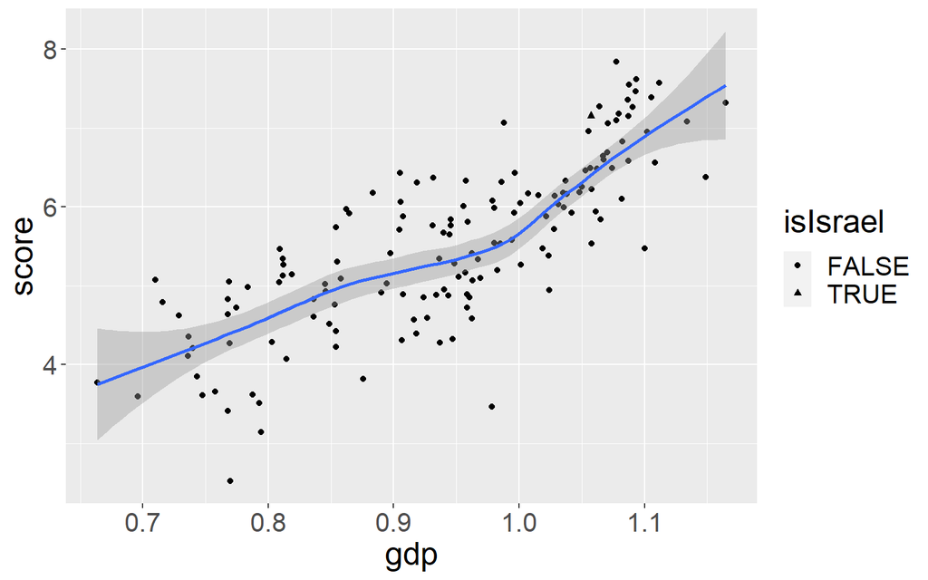

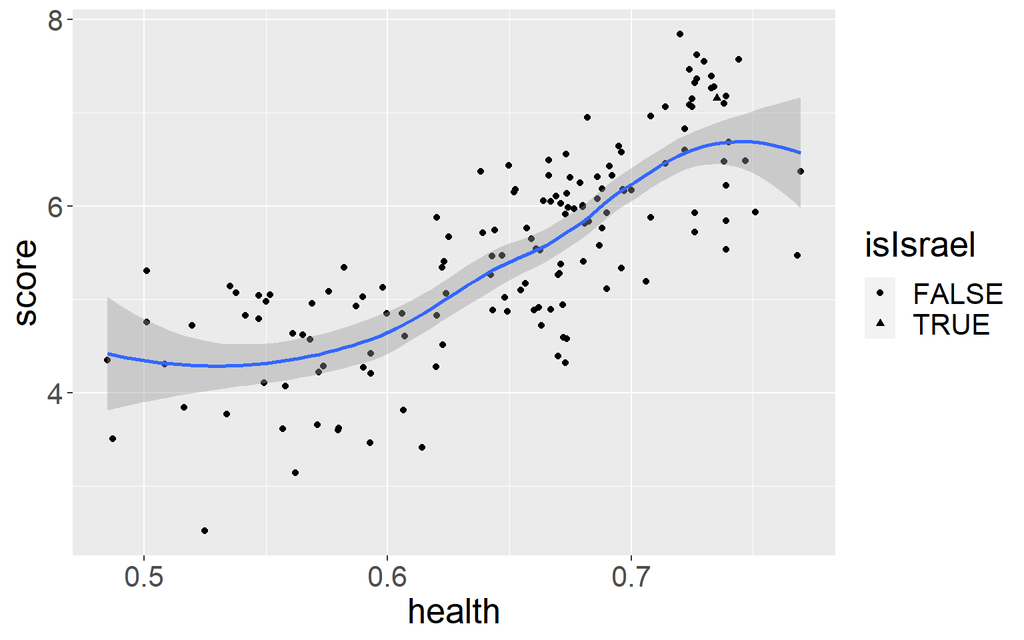

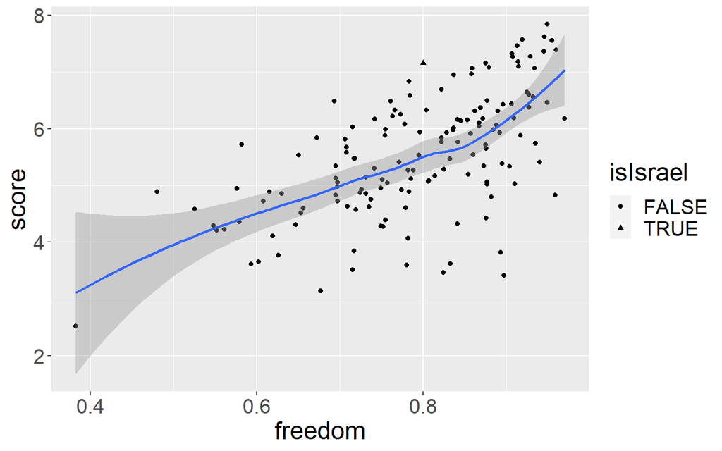

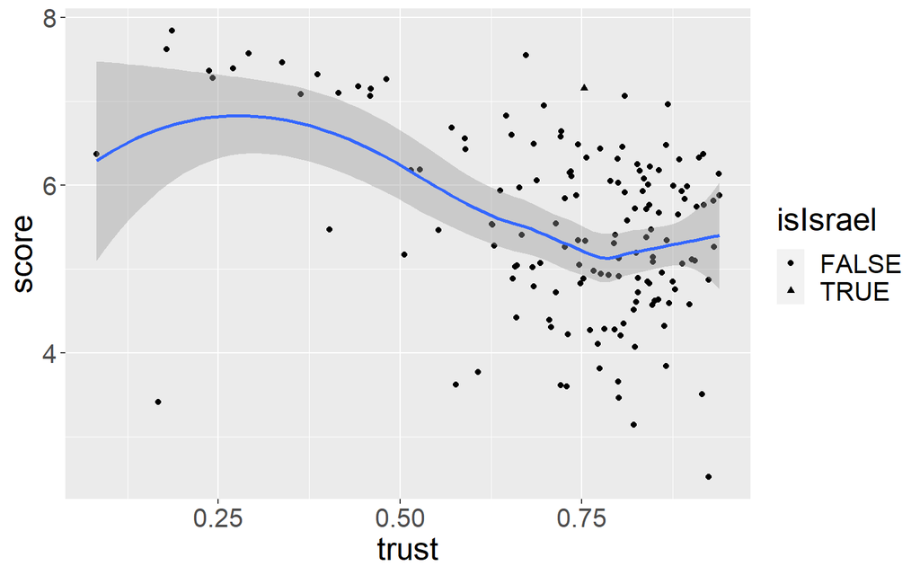

The correlations `score~gdp` and `score~freedom` looks linear. `score~trust` does not look linear, but is `score~health` linear? lets check!

### Linear model for score ~ health

The relation between the health and the score looks like:

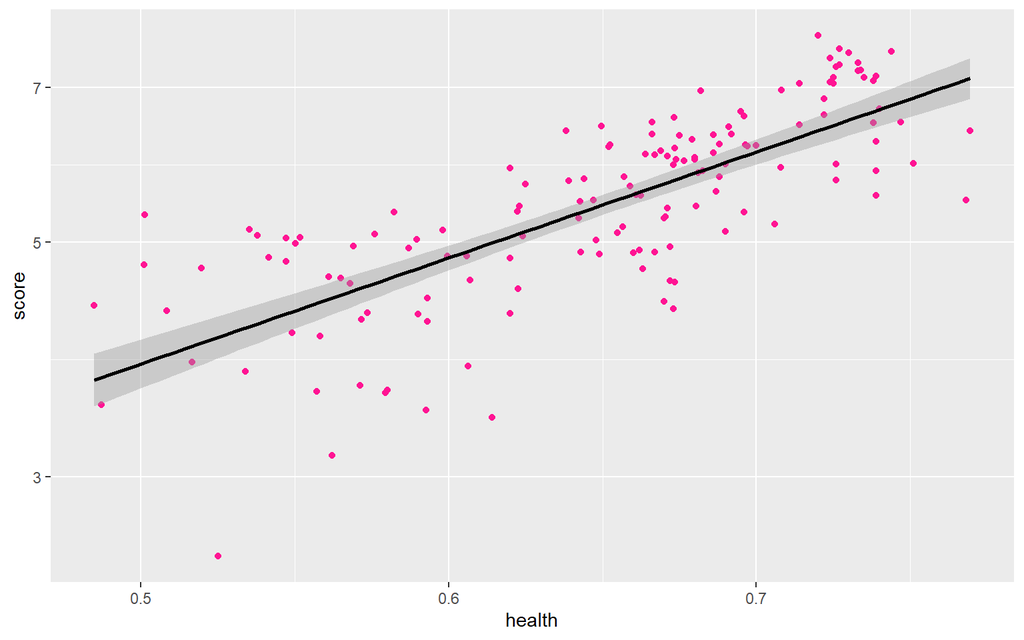

```r
# use linear model with geom_smooth
tidy21 %>% ggplot(aes(y= score , x=health ))+
geom_point(color="deeppink")+ scale_y_log10()+
stat_smooth(method = "lm",color="black")
```

```r
# linear regression test
data21_lm = lm(formula =tidy21$score ~ tidy21$health ,data=data21)
summary(data21_lm)
```

```
##
## Call:
## lm(formula = tidy21$score ~ tidy21$health, data = data21)
##
## Residuals:
##      Min       1Q   Median       3Q      Max
## -1.67956 -0.49054  0.09232  0.56360  1.58818
##
## Coefficients:
##               Estimate Std. Error t value Pr(>|t|)
## (Intercept)    -2.3954     0.5481  -4.371 2.33e-05 ***
## tidy21$health  12.1987     0.8388  14.544  < 2e-16 ***
## ---
## Signif. codes:  0 '***' 0.001 '**' 0.01 '*' 0.05 '.' 0.1 ' ' 1
##
## Residual standard error: 0.69 on 147 degrees of freedom
## Multiple R-squared:   0.59,  Adjusted R-squared:  0.5872
## F-statistic: 211.5 on 1 and 147 DF,  p-value: < 2.2e-16
```

```r
print(data21_lm)
```

```
##
## Call:
## lm(formula = tidy21$score ~ tidy21$health, data = data21)
##
## Coefficients:
##   (Intercept)  tidy21$health
##        -2.395         12.199
```

The R-Squared is 0.59. This means that around 60% of the variation in the dependent variable is explained by the independent variable.  
`p-Value` < 2.2e-16 - We can consider a linear model to be statistically significant only when the `p-Value` is less that the statistical significance level, which is 0.05.

We have two assumptions about the regression model:  
* Residuals are homoscedastic - if the data homoscedastic we shouldn’t see any connection between the points.  
* Residuals are distributed normally- If the data are exactly normal, we expect the points to lie on a straight line on the QQ graph.

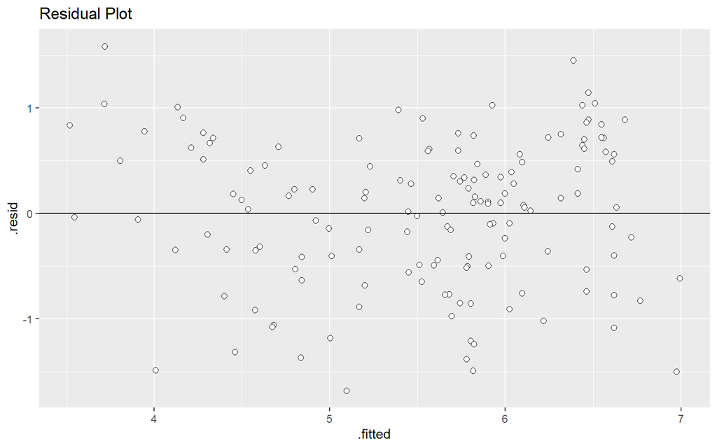

```r
# show linear model residuals on a plot
data21_lm %>% ggplot(aes(x=.fitted,y=.resid, frame=FALSE)) +
geom_point(fill="white", shape=21, size=2) + geom_hline(yintercept=0) +
labs(title="Residual Plot")
```

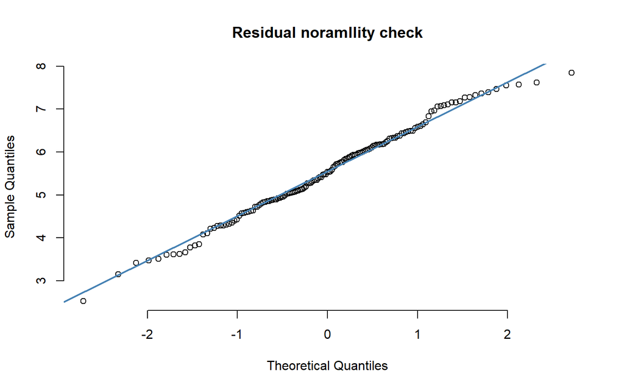

```r
# show qqplot to test normal distribution
 qqnorm(tidy21$score, pch = 1, frame = FALSE, main="Residual noramllity check")
 qqline(tidy21$score, col = "steelblue", lwd = 2)
```

#### conclusion

This results we can determine there is a linear correlation between score and Healthy life expectancy.

## 1.2 Connection between region and score

How does the area you live in effect your happiness ?

Let’s see the score of the different regions:

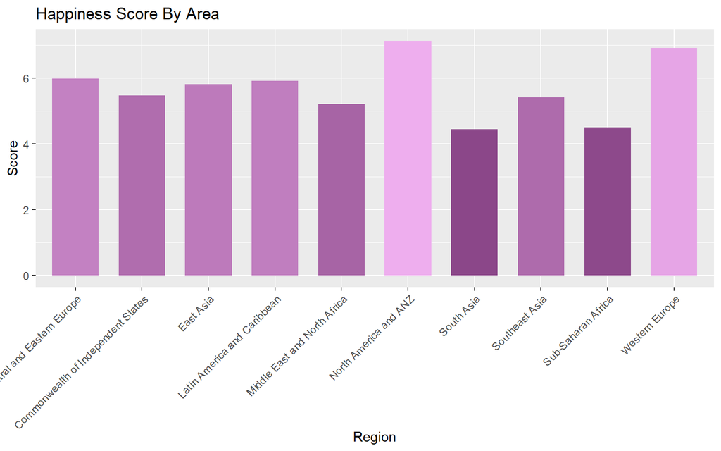

```r
# calculate mean of each area and placed the means in a new table.
by_reg = tidy21 %>% select(region, score)
mean_by_reg = aggregate(by_reg[2], list(by_reg$region), mean)  %>% rename(Region = Group.1)


# plot geom_cols of the means:
ggplot(mean_by_reg, aes(Region, score)) + geom_col(aes(fill = score), width = 0.7) +
  ggtitle("Happiness Score By Area") + theme(legend.position="none") +
  theme(axis.text.x=element_text(angle=45, hjust=1))+ylab("Score") +
  scale_fill_gradient(low = "orchid4", high = "plum2", space = "Lab",  guide = "colourbar",  aesthetics = "fill" )
```

Next, we use chi-squared test to see if we can assume normal distribution of world happiness score in 2021:

```r
# creating groups of happiness score, to see how many measurements are actually in each group
happy_new = tidy21 %>%
  mutate(new_groups = cut(score, breaks = c(0, 4, 5, 6, 7, 8)))

# we need to make sure that there are more than 5 in each group
happy_new %>% count(new_groups)
```

```
## # A tibble: 5 x 2
##   new_groups     n
##   <fct>      <int>
## 1 (0,4]         12
## 2 (4,5]         36
## 3 (5,6]         49
## 4 (6,7]         35
## 5 (7,8]         17
```

```r
# making a test shows whats the possibility to be in each of the groups (until 4, until 5, until 6....), according to normal distribution

pnorm(q = c(4, 5, 6, 7, 8), mean = mean(tidy21$score), sd = sd(tidy21$score))
```

```
## [1] 0.07674299 0.30989043 0.66822025 0.91405704 0.98920014
```

```r
#multiple by the number of countries (153) we will get the expected cumulative
expected_cum = pnorm(q = c(4, 5, 6, 7, 8), mean = mean(tidy21$score), sd = sd(tidy21$score)) *149

# to see the exact number of expediency we will have to subtract the wanted group with all of her previous
expected = expected_cum[1:5] - c(0, expected_cum[1:4])

by_group = happy_new %>% count(new_groups, name = "observed") %>% mutate(expected = expected) %>% mutate(chi = ((expected-observed)^2)/expected)
chi_sq = sum(by_group$chi)
chi_sq
```

```
## [1] 3.515746
```

```r
#table value:
qchisq(p = 1-0.05, df = 5-2-1)
```

```
## [1] 5.991465
```

The chi-squared test’s actual result is smaller than theoretical one ! This means we are going to accept the assumption that the world happiness distribution is normal.

What we’re now interested in is whether western countries are happier than non-western countries. We can perform hypothesis testing to examine this.

$h_0$: Mean of western countries score equals to score’s $\mu$ (expectation)  
$h_1$: Mean of western countries score greater then score’s $\mu$ (expectation)

```r
# filter only western countries
west = tidy21 %>% filter(region %in% c("Western Europe", "North America and ANZ"))
mu = mean(tidy21$score)

# t.test agains total mu
t.test(x = west$score, alternative = "greater", mu = mu, conf.level = 0.99)
```

```
##
##  One Sample t-test
##
## data:  west$score
## t = 11.674, df = 24, p-value = 1.103e-11
## alternative hypothesis: true mean is greater than 5.532839
## 99 percent confidence interval:
##  6.646736      Inf
## sample estimates:
## mean of x
##   6.94908
```

`p-value` < 0.01. We here by reject $h_0$. Mean of western countries is greater than total mean. We were right in 99% !

This is also noticeable in a boxplot:

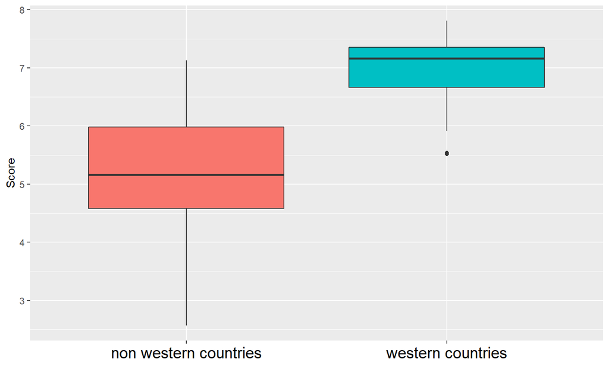

```r
# add coulmn indicate if western or not
tidy20 = tidy20 %>% mutate(isWest = ifelse(region %in% c("Western Europe", "North America and ANZ")
                                           , "western countries" , "non western countries"))

# show plot
tidy20 %>%
  ggplot(aes(y=score, x=factor(isWest) ,fill=(isWest), width = 0.5))  + geom_boxplot() +
  theme(legend.position="none", axis.text.x = element_text(color = "black", size = 15 )) + xlab("") + ylab("Score")
```

# 2. Happiness over the years

## 2.1 Covid-19 impact

How did corona virus pandemic, occurred in 2020, effect the post-covid happiness in 2021? We hypothesise that the pandemic has decreased world happiness:

$h_{0}$: the world happiness was the same during 2019 (before) and 2021 (after).  
$h_{1}$: world happiness was higher in 2019 than in 2021 - the corona virus caused the world happiness to decrease.

```r
t.test(x = score_yearly$score21 , y = score_yearly$score19 , paired = TRUE, alternative = "less")
```

```
##
##  Paired t-test
##
## data:  score_yearly$score21 and score_yearly$score19
## t = 3.4829, df = 136, p-value = 0.9997
## alternative hypothesis: true difference in means is less than 0
## 95 percent confidence interval:
##       -Inf 0.1167053
## sample estimates:
## mean of the differences
##              0.07909489
```

We can see that the `p-value` is very high. This means we cannot reject $h_0$.  
To our surprise - The corona pandemic did not impact happiness like we thought.

Let’s take a look at the findings with boxplots:

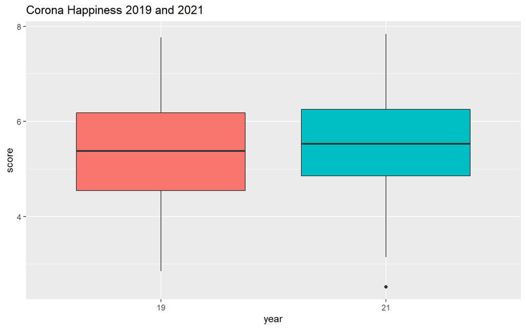

```r
entire_data %>% filter(year %in% c(19,21)) %>% ggplot(aes(y= score, x=factor(year) ,fill=factor(year)), color = year) + geom_boxplot() +
  ggtitle("Corona Happiness 2019 and 2021") + xlab("year") + theme(legend.position="none")
```

We can see that the mean happiness score is higher in 2021 than in 2019 lets make a paird t-test to check it:

```r
t.test(x = score_yearly$score21 , y = score_yearly$score19 , paired = TRUE, alternative = "greater")
```

```
##
##  Paired t-test
##
## data:  score_yearly$score21 and score_yearly$score19
## t = 3.4829, df = 136, p-value = 0.0003338
## alternative hypothesis: true difference in means is greater than 0
## 95 percent confidence interval:
##  0.04148444        Inf
## sample estimates:
## mean of the differences
##              0.07909489
```

It is true, `p-value` < 0.05. According to this test 2021’s happiness **is greater** then 2019.

## 2.2 Best year so far

To compare the happiness between the years, we started with a simple histogram - showing what scores are common for every year:

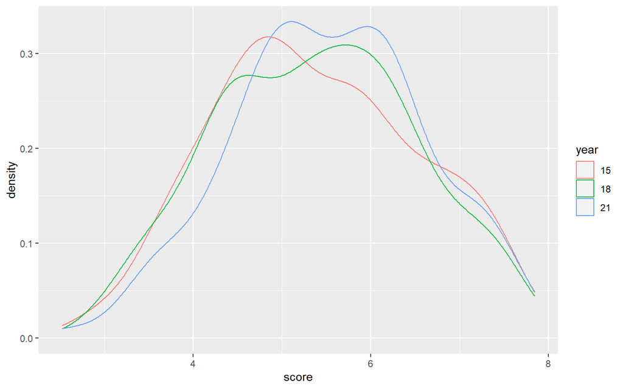

```r
some_data %>% ggplot(aes(x=`score`, color=year)) + geom_density()
```

It seems that the world is getting happier, higher scores are getting more common. Let’s see if we can see this effect in the mean score of every year:

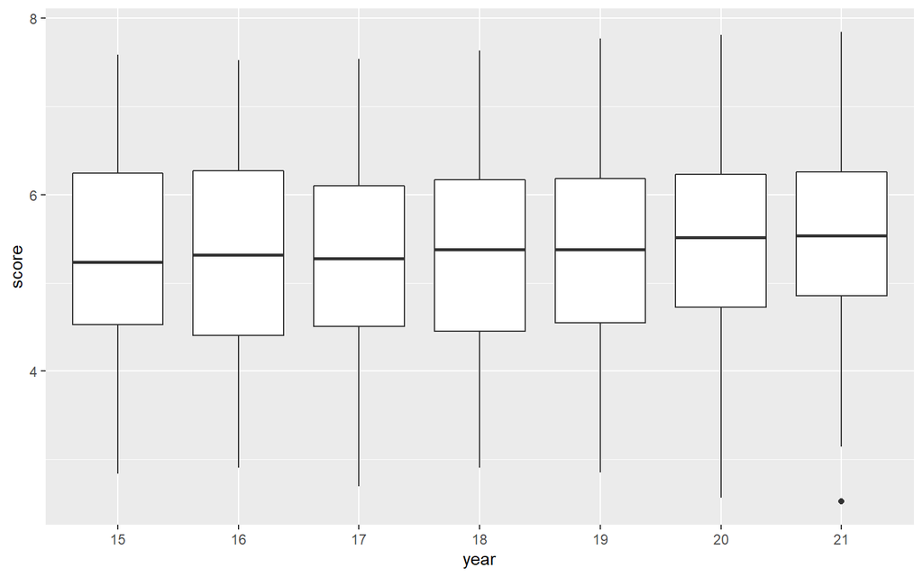

```r
entire_data %>% ggplot(aes(y=score, x=year))  + geom_boxplot()
```

This is a bit crowded, let’s again focus on 2015, 2018 and 2021

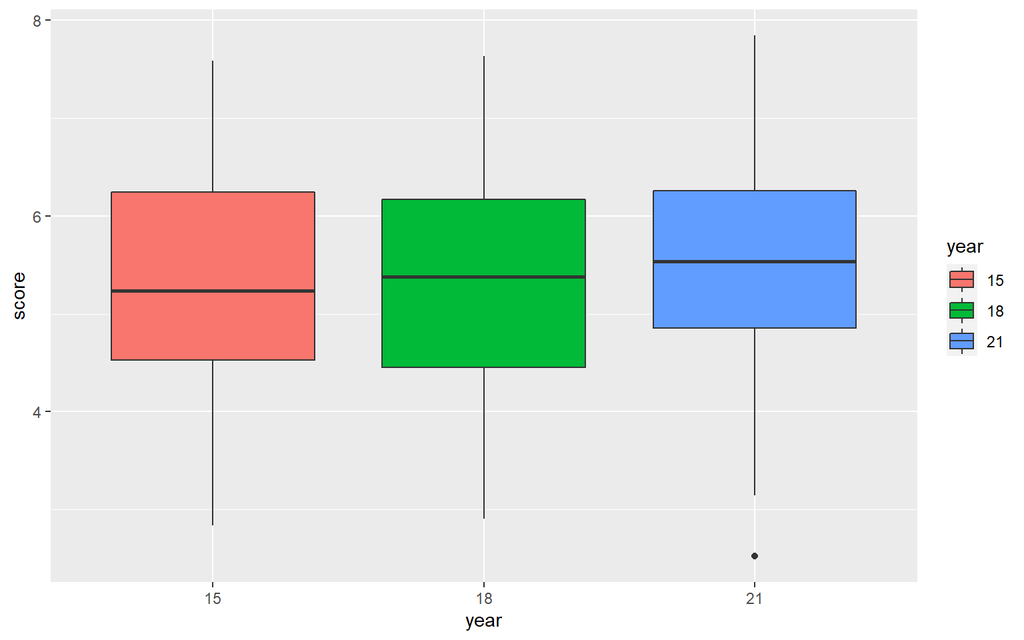

```r
some_data %>% ggplot(aes(y=score, x=year,fill=year))  + geom_boxplot()
```

This plot shows us three important things:  
1. `Mean` is higher in 2021  
2. `Variance` is lower in 2021  
3. `Mean` is higher in 2018 compared with 2015, but variance is the same

It does seem 2021 has been better, for most countries.  
Generally, the world is getting happier and during the pandemic, this process accelerated!

One explanation for this might be that when things get tough, perception of happiness increases because our day to day troubles seem less significant.

Next, we try isolate what in those years made people happier:

### Happiness over the years - diffrent variables

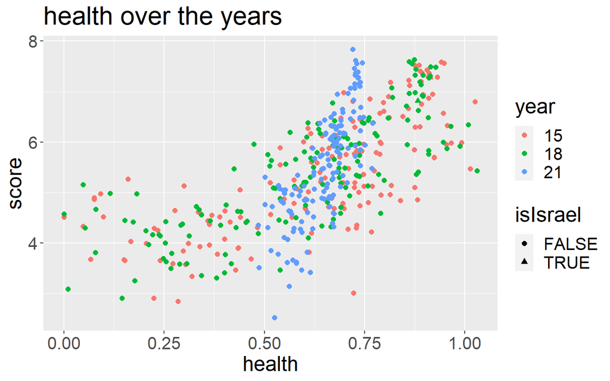

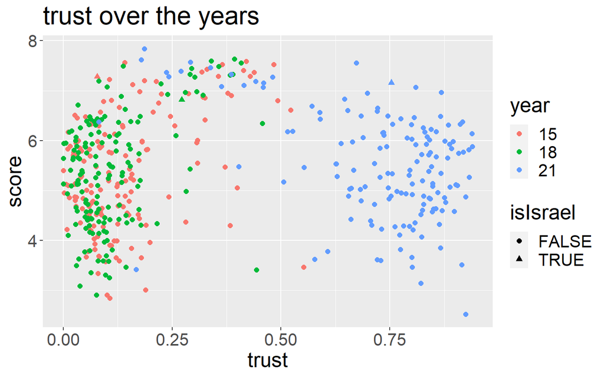

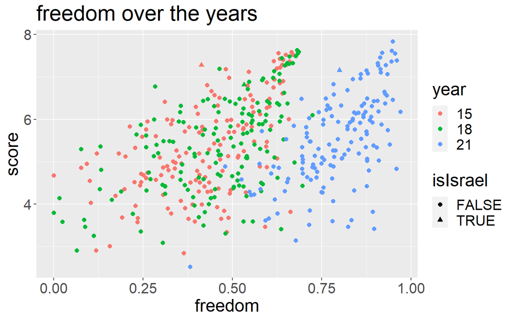

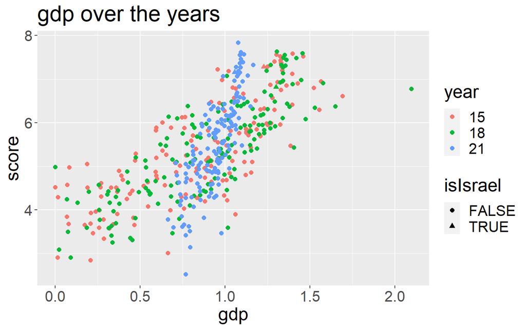